# 4 WIRKUNG DES BERATUNGSANGEBOT AUF DIE FÖRDERUNG DER LAUFBAHNRESSOURCEN

## Methoden

Methoden wären 20 Prädiktoren… problematisch.

```r
methoden_mutate <- function(x) {
    as.numeric(x) %>% recode(`1` = 0, `2` = 1)
}
methoden <- df_brm %>% select(starts_with("B2_A4")) %>% mutate(across(.fns = methoden_mutate))
psych::vss(methoden, cor = "poly")
psych::fa(methoden, nfactors = 3, cor = "poly")
```

Bei grobem druberschauen keine klare Lösung.

```r
source("../lib/numeric_conv.R")
df_brm <- df_brm %>% mutate(across(c(starts_with("A2_B3SQ"), "B1_amf"), .fns = fact_to_num))
```

Deskription

```r
 df_brm %>% select(starts_with("B2_A4")) %>% sjmisc::frq()
```

GLM für einzelne Methoden.

Für A2_B3 (4 Ressourcen)

Für die Ressourcen von T3. Hier mal mit gesamtfaktor probieren.

```r
psych::alpha(x = tmp,
             keys = rep(1,11))
```

```
Reliability analysis
Call: psych::alpha(x = tmp, keys = rep(1, 11))
```

|  | raw_alpha | std.alpha | G6(smc) | average_r | S/N | ase | mean | sd | median_r |
| --- | --- | --- | --- | --- | --- | --- | --- | --- | --- |
|  | 0.9266747 | 0.9289481 | 0.9368718 | 0.5430797 | 13.07422 | 0.001882725 | 2.973152 | 0.6676279 | 0.5349177 |

```
 lower alpha upper     95% confidence boundaries
0.92 0.93 0.93

 Reliability if an item is dropped:
```

|  | raw_alpha | std.alpha | G6(smc) | average_r | S/N | alpha se | var.r | med.r |
| --- | --- | --- | --- | --- | --- | --- | --- | --- |
| A3_A1SQ001 | 0.9194229 | 0.9217733 | 0.9294329 | 0.5409338 | 11.78335 | 0.002082030 | 0.009376308 | 0.5325878 |
| A3_A1SQ002 | 0.9193068 | 0.9216230 | 0.9277750 | 0.5404167 | 11.75884 | 0.002076742 | 0.007968146 | 0.5349177 |
| A3_A1SQ003 | 0.9184131 | 0.9207616 | 0.9287092 | 0.5374683 | 11.62014 | 0.002104817 | 0.009160482 | 0.5325878 |
| A3_A1SQ004 | 0.9189706 | 0.9210772 | 0.9294724 | 0.5385454 | 11.67060 | 0.002093808 | 0.009123464 | 0.5345099 |
| A3_A1SQ005 | 0.9201215 | 0.9229645 | 0.9317913 | 0.5450621 | 11.98102 | 0.002067524 | 0.010386492 | 0.5584802 |
| A3_A1SQ006 | 0.9269679 | 0.9286964 | 0.9304244 | 0.5656807 | 13.02453 | 0.001869288 | 0.004744527 | 0.5624069 |
| A3_A1SQ007 | 0.9203205 | 0.9233549 | 0.9257920 | 0.5464267 | 12.04715 | 0.002046841 | 0.008812245 | 0.5584802 |
| A3_A1SQ008 | 0.9171936 | 0.9200819 | 0.9287317 | 0.5351605 | 11.51280 | 0.002143054 | 0.010146271 | 0.5277328 |
| A3_A1SQ009 | 0.9189355 | 0.9215619 | 0.9288212 | 0.5402068 | 11.74891 | 0.002095148 | 0.009331610 | 0.5460605 |
| A3_A1SQ010 | 0.9172614 | 0.9196802 | 0.9266512 | 0.5338047 | 11.45024 | 0.002131637 | 0.008187402 | 0.5325878 |

[output cut: 1 more lines]

```
 Item statistics
```

|  | n | raw.r | std.r | r.cor | r.drop | mean | sd |
| --- | --- | --- | --- | --- | --- | --- | --- |
| A3_A1SQ001 | 841 | 0.7721815 | 0.7760843 | 0.7507775 | 0.7186767 | 3.145065 | 0.7915491 |
| A3_A1SQ002 | 821 | 0.7636609 | 0.7788512 | 0.7604965 | 0.7160062 | 3.001218 | 0.8503936 |
| A3_A1SQ003 | 814 | 0.7787854 | 0.7946260 | 0.7731150 | 0.7384248 | 3.111794 | 0.8261015 |
| A3_A1SQ004 | 811 | 0.7746213 | 0.7888634 | 0.7646780 | 0.7323559 | 3.019729 | 0.7743451 |
| A3_A1SQ005 | 879 | 0.7607735 | 0.7539966 | 0.7199299 | 0.6980348 | 3.064846 | 0.9213389 |
| A3_A1SQ006 | 847 | 0.6717227 | 0.6436794 | 0.6131091 | 0.5721530 | 2.886659 | 1.0077239 |
| A3_A1SQ007 | 854 | 0.7641313 | 0.7466952 | 0.7300172 | 0.6956321 | 2.809133 | 0.9500347 |
| A3_A1SQ008 | 875 | 0.8052245 | 0.8069734 | 0.7850442 | 0.7608850 | 2.981714 | 0.8779706 |
| A3_A1SQ009 | 858 | 0.7776779 | 0.7799739 | 0.7568730 | 0.7232915 | 2.980186 | 0.8713401 |
| A3_A1SQ010 | 820 | 0.7967940 | 0.8142277 | 0.8001484 | 0.7621612 | 2.970732 | 0.8482529 |

[output cut: 1 more lines]

```
Non missing response frequency for each item
              1    2    3    4 miss
A3_A1SQ001 0.06 0.08 0.52 0.34 0.76
A3_A1SQ002 0.08 0.12 0.52 0.28 0.76
A3_A1SQ003 0.06 0.10 0.50 0.34 0.76
A3_A1SQ004 0.06 0.10 0.59 0.25 0.76
A3_A1SQ005 0.08 0.14 0.40 0.38 0.74
A3_A1SQ006 0.13 0.19 0.35 0.33 0.75
A3_A1SQ007 0.12 0.21 0.42 0.26 0.75
A3_A1SQ008 0.09 0.13 0.49 0.29 0.75
A3_A1SQ009 0.08 0.14 0.49 0.29 0.75
A3_A1SQ010 0.08 0.13 0.53 0.26 0.76
A3_A1SQ011 0.15 0.21 0.42 0.21 0.80
```

```r
a3a1_methoden <- map_dfr(methodenvarnames, function(x) {
  formula <- str_c("a3_a1_total ~ ", x, "+ B1_amf + (1 | Kanton)")
  lmer(formula, data = df_brm) %>% tidy()
})
```

```
Error in map(.x, .f, ...) : object 'methodenvarnames' not found
```

### Methoden - Zielerreichung

VIelleicht mal auf die Zielerreichung schauen. Nur primärziel.

```r
a3a1_methoden <- map_dfr(methodenvarnames, function(x) {
  formula <- str_c("A3_C2SQ001 ~ ", x, "+ B1_amf + (1 | Kanton)")
  lmer(formula, data = tmp) %>% tidy()
})

a3a1_methoden %>% filter(term != "(Intercept)" & term != "B1_amf") %>%
  filter(p.value <= 0.05)  %>% write.table(., "clipboard", sep="\t", row.names=FALSE)
```

Für spezifische Ziele

```r
 write.table(., "clipboard", sep="\t", row.names=FALSE)
```

Abweichungen in Prozent vom Durchschnitt

```r
vgl1 <- df_brm %>% filter(A1_GruendeSQ006 != "Ja" & A1_GruendeSQ009 != "Ja") %>%
  select(A2_B3SQ001:A2_B3SQ004) %>%
     mutate(across(.fns = fact_to_num)) %>%
    set_label(c("Wissen über berufliche Möglichkeiten",
                "persönliche berufliche Ziele und nächste Schritte kennen",
                "Zutrauen, in meiner Laufbahn erfolgreich zu sein",
                "Motivation zur aktiven Laufbahngestaltung")) %>%
    sjmisc::frq()

vgl_unsicher <- df_brm %>% filter(A1_GruendeSQ006 == "Ja") %>%
  select(A2_B3SQ001:A2_B3SQ004) %>%
     mutate(across(.fns = fact_to_num)) %>%
    set_label(c("Wissen über berufliche Möglichkeiten",
                "persönliche berufliche Ziele und nächste Schritte kennen",
                "Zutrauen, in meiner Laufbahn erfolgreich zu sein",
                "Motivation zur aktiven Laufbahngestaltung")) %>%
    sjmisc::frq()

vgl_zufr <- df_brm %>% filter(A1_GruendeSQ009 == "Ja") %>%
  select(A2_B3SQ001:A2_B3SQ004) %>%
     mutate(across(.fns = fact_to_num)) %>%
    set_label(c("Wissen über berufliche Möglichkeiten",
                "persönliche berufliche Ziele und nächste Schritte kennen",
                "Zutrauen, in meiner Laufbahn erfolgreich zu sein",
                "Motivation zur aktiven Laufbahngestaltung")) %>%
    sjmisc::frq()
```

## Zielerreichung

```r
tmp <- map(levels(df$A1_Zielezuord1), function(ziel) {
  z1 <- vector(mode = "numeric", nrow(df_brm))
  z2 <- vector(mode = "numeric", nrow(df_brm))
  z3 <- vector(mode = "numeric", nrow(df_brm))
  z1[] <- NA
  z2[] <- NA
  z3[] <- NA

  for (i in seq_along(z1)) {

    if(!is.na(df_brm$A1_Zielezuord1[i])) {
      if(df_brm$A1_Zielezuord1[i] == ziel) {
        z1[i] <- df_brm$A2_B2SQ001[i]
    } }
    if(!is.na(df_brm$A1_Zielezuord2[i])) {
      if(df_brm$A1_Zielezuord2[i] == ziel) {
        z2[i] <- df_brm$A2_B2SQ002[i]
    } }
    if(!is.na(df_brm$A1_Zielezuord3[i])) {
      if(df_brm$A1_Zielezuord3[i] == ziel) {
        z3[i] <- df_brm$A2_B2SQ003[i]
    } }
  }

  data.frame(z1 = z1, z2 = z2,z3 = z3) %>%
    mutate(ziel = ziel) %>%
    pivot_longer(-ziel, names_to = "zielnum")
})
tmp <- map(levels(df$A1_Zielezuord1), function(ziel) {
  z1 <- vector(mode = "numeric", nrow(df_brm))
  z2 <- vector(mode = "numeric", nrow(df_brm))
  z3 <- vector(mode = "numeric", nrow(df_brm))
  z1[] <- NA
  z2[] <- NA
  z3[] <- NA

  for (i in seq_along(z1)) {

    if(!is.na(df_brm$A1_Zielezuord1[i])) {
      if(df_brm$A1_Zielezuord1[i] == ziel) {
        z1[i] <- df_brm$A2_B2SQ001[i]
    } }
    if(!is.na(df_brm$A1_Zielezuord2[i])) {
      if(df_brm$A1_Zielezuord2[i] == ziel) {
        z2[i] <- df_brm$A2_B2SQ002[i]
    } }
    if(!is.na(df_brm$A1_Zielezuord3[i])) {
      if(df_brm$A1_Zielezuord3[i] == ziel) {
        z3[i] <- df_brm$A2_B2SQ003[i]
    } }
  }

  data.frame(z1 = z1, z2 = z2,z3 = z3) %>%
    mutate(ziel = ziel) %>%
    pivot_longer(-ziel, names_to = "zielnum")
})
ziele_erreicht <- map_dfc(tmp, function(x) {
  out <- data.frame(x = x$value)
  names(out) <- x$ziel[1]
  out <- set_labels(out, labels = c("Überhaupt nicht hilfreich" = 1, "wenig hilfreich" = 2,
                             "eher hilfreich" = 3, "hilfreich" = 4))
  return(out)
})
```

```
Error in set_labels(out, labels = c(`Überhaupt nicht hilfreich` = 1, `wenig hilfreich` = 2,  :
  could not find function "set_labels"
```

```r
 # unfinished
tmp <- map(levels(df$A1_Zielezuord1), function(ziel) {
  z1 <- vector(mode = "numeric", nrow(df_brm))
  z2 <- vector(mode = "numeric", nrow(df_brm))
  z3 <- vector(mode = "numeric", nrow(df_brm))
  z1[] <- NA
  z2[] <- NA
  z3[] <- NA

  for (i in seq_along(z1)) {

    if(!is.na(df_brm$A1_Zielezuord1[i])) {
      if(df_brm$A1_Zielezuord1[i] == ziel) {
        z1[i] <- df_brm$A2_B2SQ001[i]
    } }
    if(!is.na(df_brm$A1_Zielezuord2[i])) {
      if(df_brm$A1_Zielezuord2[i] == ziel) {
        z2[i] <- df_brm$A2_B2SQ002[i]
    } }
    if(!is.na(df_brm$A1_Zielezuord3[i])) {
      if(df_brm$A1_Zielezuord3[i] == ziel) {
        z3[i] <- df_brm$A2_B2SQ003[i]
    } }
  }

  data.frame(z1 = z1, z2 = z2,z3 = z3) %>%
    mutate(ziel = ziel) %>%
    pivot_longer(-ziel, names_to = "zielnum")
})

ziele_erreicht <- map_dfc(tmp, function(x) {
  out <- data.frame(x = x$value)
  names(out) <- x$ziel[1]
  out <- set_labels(out, labels = c("Überhaupt nicht hilfreich" = 1, "wenig hilfreich" = 2,
                             "eher hilfreich" = 3, "hilfreich" = 4))
  return(out)
})


names(ziele_erreicht) <- c("Allgemeine Fähigkeiten",
                     "Arbeitseinsatz",
                     "Arbeitsmarktwissen",
                     "Berufliche Expertise",
                     "Entwicklungsmöglichkeiten beim jetzigen Arbeitgeber",
                     "Klarheit",
                     "Netzwerken",
                     "Sonstiges",
                     "Unterstützung durch soziales Umfeld",
                     "Zutrauen")


ziele_erreicht %>% sjPlot::plot_stackfrq(show.prc = FALSE, sort.frq = "last.desc") +
      geom_text(
      aes(y = .data$ypos, label = likert_labeller(.data$prc)), size = 3.5) +
    theme(legend.position = "bottom") +
  guides(fill=guide_legend(nrow=2,byrow=TRUE))


ggsave("plots/ziele_erreicht_a3.png", width = 6.27, height = 5)
```

# Gruende - A2 Ressourcen

```r
glm_outc_gruende <- map2_dfr(outcome_gruende_pairs$outcomevarnames, outcome_gruende_pairs$gruendenames, function(y,x) {
  glm_formula <- str_c(y, " ~ ", x, "+ B1_amf")
  glm(glm_formula, family = gaussian(link = "identity"), data = df_brm) %>% tidy() %>% mutate(outcome = y)
})
```

```
Error in eval(predvars, data, env) : object 'A2_B3_total' not found
```

## A3A1 : 11 ASpekte der Ressourcenförderung

```
Very Simple Structure
Call: psych::vss(x = df_brm %>% select(starts_with("A3_A1SQ")))
VSS complexity 1 achieves a maximimum of 0.93  with  1  factors
VSS complexity 2 achieves a maximimum of 0.96  with  2  factors

The Velicer MAP achieves a minimum of 0.03  with  2  factors
BIC achieves a minimum of  8.67  with  6  factors
Sample Size adjusted BIC achieves a minimum of  21.38  with  6  factors

Statistics by number of factors
```

| vss1 | vss2 | map | dof | chisq | prob | sqresid | fit | RMSEA | BIC | SABIC | complex | eChisq | SRMR | eCRMS | eBIC |
| --- | --- | --- | --- | --- | --- | --- | --- | --- | --- | --- | --- | --- | --- | --- | --- |
| 0.9329288 | 0.0000000 | 0.03550348 | 44 | 3.513081e+03 | 0.000000e+00 | 2.9446381 | 0.9329288 | 0.15145733 | 3154.817205 | 3294.62598 | 1.000000 | 1.957494e+03 | 7.195551e-02 | 0.08044871 | 1599.23005 |
| 0.6791006 | 0.9608069 | 0.03183851 | 34 | 1.064350e+03 | 1.544669e-201 | 1.7207012 | 0.9608069 | 0.09389902 | 787.509869 | 895.54392 | 1.405018 | 3.147603e+02 | 2.885385e-02 | 0.03669828 | 37.92021 |
| 0.4670354 | 0.8188699 | 0.04387362 | 25 | 4.438382e+02 | 3.088707e-78 | 1.4234694 | 0.9675770 | 0.06981674 | 240.279322 | 319.71612 | 1.934356 | 1.150017e+02 | 1.744078e-02 | 0.02586886 | -88.55716 |
| 0.3388753 | 0.7187255 | 0.06647781 | 17 | 2.565597e+02 | 9.521541e-45 | 1.2447356 | 0.9716481 | 0.06403069 | 118.139680 | 172.15671 | 2.337892 | 5.110960e+01 | 1.162693e-02 | 0.02091327 | -87.31042 |
| 0.2838525 | 0.5545222 | 0.10309900 | 10 | 1.188100e+02 | 8.821431e-21 | 1.1371099 | 0.9740996 | 0.05626507 | 37.386493 | 69.16121 | 2.641830 | 2.377057e+01 | 7.929279e-03 | 0.01859581 | -57.65297 |
| 0.3594659 | 0.6510431 | 0.12885219 | 4 | 4.124057e+01 | 2.396549e-08 | 0.9551362 | 0.9782445 | 0.05204531 | 8.671149 | 21.38104 | 2.518537 | 6.903828e+00 | 4.273256e-03 | 0.01584566 | -25.66559 |
| 0.3372336 | 0.6550407 | 0.18917359 | -1 | 1.115077e+01 | NA | 0.8314442 | 0.9810619 | NA | NA | NA | 2.564931 | 1.943820e+00 | 2.267472e-03 | NA | NA |
| 0.2621565 | 0.4606554 | 0.30221024 | -5 | 4.390691e-07 | NA | 0.8046410 | 0.9816724 | NA | NA | NA | 2.981762 | 7.688714e-08 | 4.509628e-07 | NA | NA |

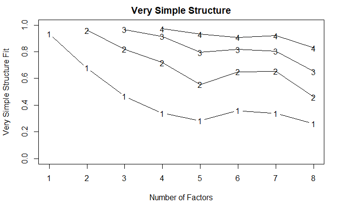

```r
psych::vss(df_brm %>% select(starts_with("A3_A1SQ")))
```

```
Very Simple Structure
Call: psych::vss(x = df_brm %>% select(starts_with("A3_A1SQ")))
VSS complexity 1 achieves a maximimum of 0.93  with  1  factors
VSS complexity 2 achieves a maximimum of 0.96  with  2  factors

The Velicer MAP achieves a minimum of 0.03  with  2  factors
BIC achieves a minimum of  8.67  with  6  factors
Sample Size adjusted BIC achieves a minimum of  21.38  with  6  factors

Statistics by number of factors
```

| vss1 | vss2 | map | dof | chisq | prob | sqresid | fit | RMSEA | BIC | SABIC | complex | eChisq | SRMR | eCRMS | eBIC |
| --- | --- | --- | --- | --- | --- | --- | --- | --- | --- | --- | --- | --- | --- | --- | --- |
| 0.9329288 | 0.0000000 | 0.03550348 | 44 | 3.513081e+03 | 0.000000e+00 | 2.9446381 | 0.9329288 | 0.15145733 | 3154.817205 | 3294.62598 | 1.000000 | 1.957494e+03 | 7.195551e-02 | 0.08044871 | 1599.23005 |
| 0.6791006 | 0.9608069 | 0.03183851 | 34 | 1.064350e+03 | 1.544669e-201 | 1.7207012 | 0.9608069 | 0.09389902 | 787.509869 | 895.54392 | 1.405018 | 3.147603e+02 | 2.885385e-02 | 0.03669828 | 37.92021 |
| 0.4670354 | 0.8188699 | 0.04387362 | 25 | 4.438382e+02 | 3.088707e-78 | 1.4234694 | 0.9675770 | 0.06981674 | 240.279322 | 319.71612 | 1.934356 | 1.150017e+02 | 1.744078e-02 | 0.02586886 | -88.55716 |
| 0.3388753 | 0.7187255 | 0.06647781 | 17 | 2.565597e+02 | 9.521541e-45 | 1.2447356 | 0.9716481 | 0.06403069 | 118.139680 | 172.15671 | 2.337892 | 5.110960e+01 | 1.162693e-02 | 0.02091327 | -87.31042 |
| 0.2838525 | 0.5545222 | 0.10309900 | 10 | 1.188100e+02 | 8.821431e-21 | 1.1371099 | 0.9740996 | 0.05626507 | 37.386493 | 69.16121 | 2.641830 | 2.377057e+01 | 7.929279e-03 | 0.01859581 | -57.65297 |
| 0.3594659 | 0.6510431 | 0.12885219 | 4 | 4.124057e+01 | 2.396549e-08 | 0.9551362 | 0.9782445 | 0.05204531 | 8.671149 | 21.38104 | 2.518537 | 6.903828e+00 | 4.273256e-03 | 0.01584566 | -25.66559 |
| 0.3372336 | 0.6550407 | 0.18917359 | -1 | 1.115077e+01 | NA | 0.8314442 | 0.9810619 | NA | NA | NA | 2.564931 | 1.943820e+00 | 2.267472e-03 | NA | NA |
| 0.2621565 | 0.4606554 | 0.30221024 | -5 | 4.390691e-07 | NA | 0.8046410 | 0.9816724 | NA | NA | NA | 2.981762 | 7.688714e-08 | 4.509628e-07 | NA | NA |

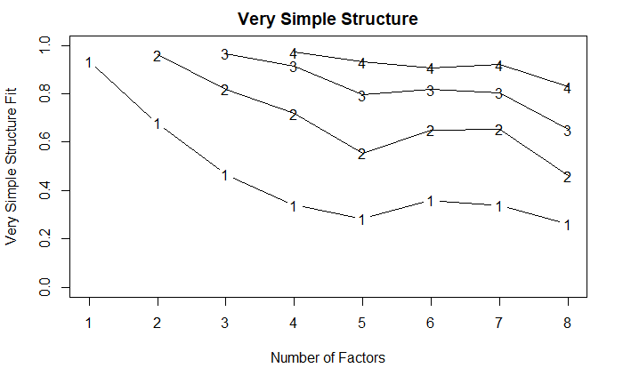

```r
psych::vss(df_brm %>% select(starts_with("A3_A1SQ")))
```

```r
psych::fa(df_brm %>% select(starts_with("A3_A1SQ")), nfactors = 2)
```

```
Factor Analysis using method =  minres
Call: psych::fa(r = df_brm %>% select(starts_with("A3_A1SQ")),
    nfactors = 2)
Standardized loadings (pattern matrix) based upon correlation matrix
```

|  | MR1 | MR2 | h2 | u2 | com |
| --- | --- | --- | --- | --- | --- |
| A3_A1SQ001 | 0.76 | 0.02 | 0.5954743 | 0.4045257 | 1.001466 |
| A3_A1SQ002 | 0.87 | -0.12 | 0.6519059 | 0.3480941 | 1.035155 |
| A3_A1SQ003 | 0.76 | 0.03 | 0.6158585 | 0.3841415 | 1.003520 |
| A3_A1SQ004 | 0.76 | 0.03 | 0.6096190 | 0.3903810 | 1.003389 |
| A3_A1SQ005 | 0.41 | 0.41 | 0.5432525 | 0.4567475 | 1.999655 |
| A3_A1SQ006 | -0.06 | 0.87 | 0.6980538 | 0.3019462 | 1.010267 |
| A3_A1SQ007 | 0.09 | 0.84 | 0.7972416 | 0.2027584 | 1.021668 |
| A3_A1SQ008 | 0.56 | 0.30 | 0.6123498 | 0.3876502 | 1.533018 |
| A3_A1SQ009 | 0.69 | 0.10 | 0.5821359 | 0.4178641 | 1.044572 |
| A3_A1SQ010 | 0.87 | -0.06 | 0.6970608 | 0.3029392 | 1.009415 |

[output cut: 1 more lines]

```
                       MR1  MR2
SS loadings           4.88 1.99
Proportion Var        0.44 0.18
Cumulative Var        0.44 0.62
Proportion Explained  0.71 0.29
Cumulative Proportion 0.71 1.00

 With factor correlations of
     MR1  MR2
MR1 1.00 0.61
MR2 0.61 1.00

Mean item complexity =  1.2
Test of the hypothesis that 2 factors are sufficient.

The degrees of freedom for the null model are  55  and the objective function was  7.11 with Chi Square of  24414.72
The degrees of freedom for the model are 34  and the objective function was  0.31

The root mean square of the residuals (RMSR) is  0.03
The df corrected root mean square of the residuals is  0.04

The harmonic number of observations is  774 with the empirical chi square  71.38  with prob <  0.00018
The total number of observations was  3437  with Likelihood Chi Square =  1064.35  with prob <  1.5e-201

Tucker Lewis Index of factoring reliability =  0.932
RMSEA index =  0.094  and the 90 % confidence intervals are  0.089 0.099
BIC =  787.51
Fit based upon off diagonal values = 1
Measures of factor score adequacy
                                                   MR1  MR2
Correlation of (regression) scores with factors   0.96 0.94
Multiple R square of scores with factors          0.93 0.88
Minimum correlation of possible factor scores     0.86 0.76
```

Grob zwei Bereiche: 1) Weiterentwicklung mit Sq006 und 007, 2) der Rest.

## A3a1 AMF und CRQ

```r
glm_outc_a3a1_crq <- map_dfr(ressourcennames, function(y) {
  formula <- str_c(y, " ~ I(scale(knsk))+ I(scale(mot)) + I(scale(act)) + I(scale(env)) + (1 | Kanton)")
  lmer(formula, data = df_brm) %>% tidy() %>% mutate(outcome = y)
})
```

```
boundary (singular) fit: see ?isSingular
boundary (singular) fit: see ?isSingular
```

```r
glm_outc_a3a1_crq <- map_dfr(ressourcennames, function(y) {
  formula <- str_c(y, " ~ I(scale(knsk))+ I(scale(mot)) + I(scale(act)) + I(scale(env)) + (1 | Kanton)")
  lmer(formula, data = df_brm) %>% tidy() %>% mutate(outcome = y)
})
```

```
boundary (singular) fit: see ?isSingular
boundary (singular) fit: see ?isSingular
```

```r
glm_outc_a3a1_crq %>% filter(term != "(Intercept)") %>%
  filter(p.value <= 0.05) %>% arrange(outcome) %>% write.table(., "clipboard", sep="\t", row.names=FALSE)
```

## A3A1 RESSOURCEN TEILNAHMEGRUNDE

```r
glm_outc_gruende <- map_dfr(gruendenames, function(x) {
  formula <- str_c("a3_a1_total~ ", x, "+ B1_amf + (1 | Kanton)")
  lmer(formula, data = df_brm) %>% tidy()
})
```

```
Error in eval(predvars, data, env) : object 'a3_a1_total' not found
```

## A3C2 Zielerreichung im Followup

| effect | group | term | estimate | std.error | statistic | df | p.value | outcome |
| --- | --- | --- | --- | --- | --- | --- | --- | --- |
| fixed | NA | A1_GruendeSQ006Ja | -0.2691226 | 0.1176601 | -2.287288 | 358 | 0.02276189 | A3_C2SQ001 |
| fixed | NA | A1_GruendeSQ009Ja | -0.2227749 | 0.1088087 | -2.047399 | 358 | 0.04134835 | A3_C2SQ001 |

# Korrespondenz CRQ - Inhaltlicher Fokus

Variablenset 1: ksnk + mot + act + env Variablenset 2: B2_A1[SQ001] bis B2_A1[SQ001]

Korrespondenz coden als? - Knsk niedriger (z-standardisiert, ipsativiert?) - ziel gewählt. Qualitativ kodieren?

## Deskriptive Statistiken - Plots

siehe alle plots file